# Fitness Data

CK

November 18, 2014

### Apply Machine Learning Alogrithms for Establish Fitness Exercise Corectness

The goal of this project is to predict the manner in which they did the exercise. To do this we are going to analze the data fro from this source: http://groupware.les.inf.puc-rio.br/har.

Loading the required R Libraries.

```r
setwd("~/Documents/R/ML_fitness")
library(caret)
```

```r
library(ggplot2)
library(rpart.plot)
library(corrplot)
```

Two datasets downloaed from the internet and then two local files created.

```r
#file sdownload
download.file("http://d396qusza40orc.cloudfront.net/predmachlearn/pml-training.csv",
destfile="training.csv")
download.file("http://d396qusza40orc.cloudfront.net/predmachlearn/pml-testing.csv",
destfile="test.csv")

#load data
training<-read.csv("training.csv")
test<-read.csv("test.csv")
head(training)
```

[output not shown]

[output cut: 265 more lines]

With data cleaning process we choose the colomuns that we are going to use.

```r
include.col <- c("pitch_belt", "yaw_belt", "total_accel_belt", "gyros_belt_x",
    "gyros_belt_y", "gyros_belt_z", "accel_belt_x", "accel_belt_y", "accel_belt_z",
    "magnet_belt_x", "magnet_belt_y", "magnet_belt_z", "roll_arm", "pitch_arm",
    "yaw_arm", "total_accel_arm", "gyros_arm_x", "gyros_arm_y", "gyros_arm_z",
    "accel_arm_x", "accel_arm_y", "accel_arm_z", "magnet_arm_x", "magnet_arm_y",
    "magnet_arm_z", "roll_dumbbell", "pitch_dumbbell", "yaw_dumbbell", "total_accel_dumbbell",
    "gyros_dumbbell_x", "gyros_dumbbell_y", "gyros_dumbbell_z", "accel_dumbbell_x",
    "accel_dumbbell_y", "accel_dumbbell_z", "magnet_dumbbell_x", "magnet_dumbbell_y",
    "magnet_dumbbell_z", "roll_forearm", "pitch_forearm", "yaw_forearm", "total_accel_forearm",
    "gyros_forearm_x", "gyros_forearm_y", "gyros_forearm_z", "accel_forearm_x",
    "accel_forearm_y", "accel_forearm_z", "magnet_forearm_x", "magnet_forearm_y",
    "magnet_forearm_z")
test1 <- test[, include.col]
include.col<- c(include.col, "classe")
training1 <- training[, include.col]
dim(training)
```

```
## [1] 19622   160
```

```r
dim(training1)
```

```
## [1] 19622    52
```

# Exploratory analysis

Two figures produced for the data exploratory analysis. First a histogram to count the frequency of the classe variable and second a graph which shows that how different columns are correlated to each other.

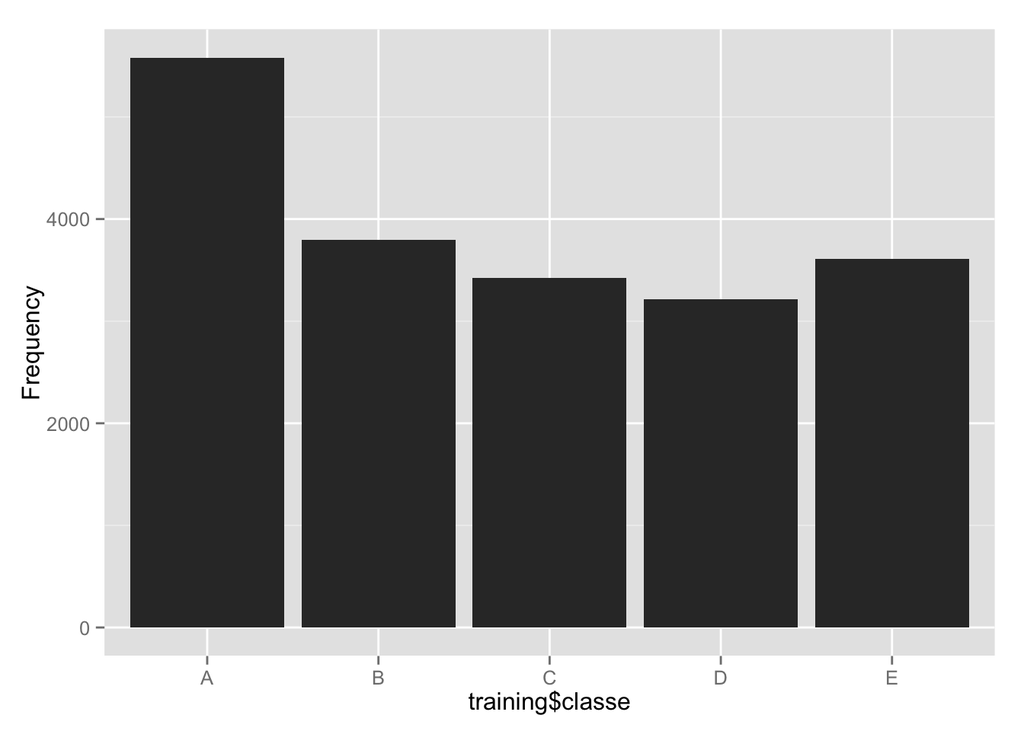

```r
qplot(training$classe, ylab="Frequency")
```

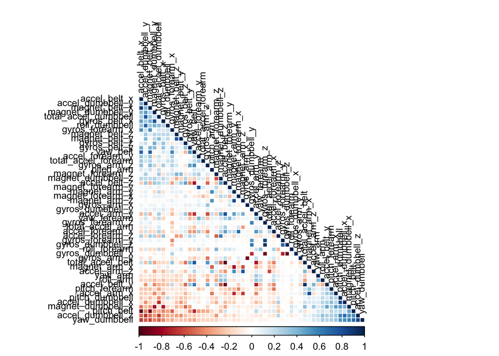

```r
corr <- cor(training1[ ,-52])
corrplot(corr, order="FPC", type="lower", method="color", tl.cex=0.8, tl.col="black")
```

# Prediction Model

We use the Randon Forest Algorithm for the following reasons. the decisions tree algorithms adavatages are: Simple to understand and interpret. People are able to understand decision tree models after a brief explanation. -Requires little data preparation. -Able to handle both numerical and categorical data. -Uses a white box model -Possible to validate a model using statistical tests. That makes it possible to account for the reliability of the model. -Robust. Performs well even if its assumptions are somewhat violated by the true model from which the data were generated.

```r
#Random Forest Algorithm
library(randomForest)
model1<-randomForest(classe ~ ., data=training1, method="class")
predict1<-predict(model1, training1, type="class")
print(confusionMatrix(predict1, training1$classe))
```

```
## Confusion Matrix and Statistics
##
##           Reference
## Prediction    A    B    C    D    E
##          A 5580    0    0    0    0
##          B    0 3797    0    0    0
##          C    0    0 3422    0    0
##          D    0    0    0 3216    0
##          E    0    0    0    0 3607
##
## Overall Statistics
##
##                Accuracy : 1
##                  95% CI : (1, 1)
##     No Information Rate : 0.284
##     P-Value [Acc > NIR] : <2e-16
##
##                   Kappa : 1
##  Mcnemar's Test P-Value : NA
##
## Statistics by Class:
##
##                      Class: A Class: B Class: C Class: D Class: E
## Sensitivity             1.000    1.000    1.000    1.000    1.000
## Specificity             1.000    1.000    1.000    1.000    1.000
## Pos Pred Value          1.000    1.000    1.000    1.000    1.000
## Neg Pred Value          1.000    1.000    1.000    1.000    1.000
## Prevalence              0.284    0.194    0.174    0.164    0.184
## Detection Rate          0.284    0.194    0.174    0.164    0.184
## Detection Prevalence    0.284    0.194    0.174    0.164    0.184
## Balanced Accuracy       1.000    1.000    1.000    1.000    1.000
```

# Testing

```r
testing_res<-predict(model1,test1)
testing_res
```

```
##  1  2  3  4  5  6  7  8  9 10 11 12 13 14 15 16 17 18 19 20
##  B  A  B  A  A  E  D  B  A  A  B  C  B  A  E  E  A  B  B  B
## Levels: A B C D E
```

# Write Files

```r
pml_write_files = function(x){
        n=length(x)
        for (i in 1:n){
          filename=paste0("problem_id_",i,".txt")
          write.table(x[i], file =filename, quote=FALSE, row.names=FALSE,col.names=FALSE)
        }
}
pml_write_files(testing_res)
```